# Testing hierarchical pathway kinetics with residue data on dimethenamid and dimethenamid-P

Johannes Ranke

Last change on 20 April 2023, last compiled on 13 Februar 2025

# Introduction

The purpose of this document is to test demonstrate how nonlinear hierarchical models (NLHM) based on the parent degradation models SFO, FOMC, DFOP and HS, with parallel formation of two or more metabolites can be fitted with the mkin package.

It was assembled in the course of work package 1.2 of Project Number 173340 (Application of nonlinear hierarchical models to the kinetic evaluation of chemical degradation data) of the German Environment Agency carried out in 2022 and 2023.

The mkin package is used in version 1.2.9, which is currently under development. It contains the test data, and the functions used in the evaluations. The `saemix` package is used as a backend for fitting the NLHM, but is also loaded to make the convergence plot function available.

This document is processed with the `knitr` package, which also provides the `kable` function that is used to improve the display of tabular data in R markdown documents. For parallel processing, the `parallel` package is used.

```r
library(mkin)
library(knitr)
library(saemix)
library(parallel)
n_cores <- detectCores()

# We need to start a new cluster after defining a compiled model that is
# saved as a DLL to the user directory, therefore we define a function
# This is used again after defining the pathway model
start_cluster <- function(n_cores) {
  if (Sys.info()["sysname"] == "Windows") {
    ret <- makePSOCKcluster(n_cores)
  } else {
    ret <- makeForkCluster(n_cores)
  }
  return(ret)
}
```

# Data

The test data are available in the mkin package as an object of class `mkindsg` (mkin dataset group) under the identifier `dimethenamid_2018`. The following preprocessing steps are done in this document.

- The data available for the enantiomer dimethenamid-P (DMTAP) are renamed to have the same substance name as the data for the racemic mixture dimethenamid (DMTA). The reason for this is that no difference between their degradation behaviour was identified in the EU risk assessment.
- Unnecessary columns are discarded
- The observation times of each dataset are multiplied with the corresponding normalisation factor also available in the dataset, in order to make it possible to describe all datasets with a single set of parameters that are independent of temperature
- Finally, datasets observed in the same soil (`Elliot 1` and `Elliot 2`) are combined, resulting in dimethenamid (DMTA) data from six soils.

The following commented R code performs this preprocessing.

```r
# Apply a function to each of the seven datasets in the mkindsg object to create a list
dmta_ds <- lapply(1:7, function(i) {
  ds_i <- dimethenamid_2018$ds[[i]]$data                     # Get a dataset
  ds_i[ds_i$name == "DMTAP", "name"] <-  "DMTA"              # Rename DMTAP to DMTA
  ds_i <- subset(ds_i, select = c("name", "time", "value")) # Select data
  ds_i$time <- ds_i$time * dimethenamid_2018$f_time_norm[i]  # Normalise time
  ds_i                                                       # Return the dataset
})

# Use dataset titles as names for the list elements
names(dmta_ds) <- sapply(dimethenamid_2018$ds, function(ds) ds$title)

# Combine data for Elliot soil to obtain a named list with six elements
dmta_ds[["Elliot"]] <- rbind(dmta_ds[["Elliot 1"]], dmta_ds[["Elliot 2"]]) #
dmta_ds[["Elliot 1"]] <- NULL
dmta_ds[["Elliot 2"]] <- NULL
```

The following tables show the 6 datasets.

```r
for (ds_name in names(dmta_ds)) {
  print(
    kable(mkin_long_to_wide(dmta_ds[[ds_name]]),
      caption = paste("Dataset", ds_name),
      booktabs = TRUE, row.names = FALSE))
    cat("\n\\clearpage\n")
}
```

Dataset Calke

| time | DMTA | M23 | M27 | M31 |
| --- | --- | --- | --- | --- |
| 0 | 95.8 | NA | NA | NA |
| 0 | 98.7 | NA | NA | NA |
| 14 | 60.5 | 4.1 | 1.5 | 2.0 |
| 30 | 39.1 | 5.3 | 2.4 | 2.1 |
| 59 | 15.2 | 6.0 | 3.2 | 2.2 |
| 120 | 4.8 | 4.3 | 3.8 | 1.8 |
| 120 | 4.6 | 4.1 | 3.7 | 2.1 |

Dataset Borstel

| time | DMTA | M23 | M27 | M31 |
| --- | --- | --- | --- | --- |
| 0.000000 | 100.5 | NA | NA | NA |
| 0.000000 | 99.6 | NA | NA | NA |
| 1.941295 | 91.9 | 0.4 | NA | NA |
| 1.941295 | 91.3 | 0.5 | 0.3 | 0.1 |
| 6.794534 | 81.8 | 1.2 | 0.8 | 1.0 |
| 6.794534 | 82.1 | 1.3 | 0.9 | 0.9 |
| 13.589067 | 69.1 | 2.8 | 1.4 | 2.0 |
| 13.589067 | 68.0 | 2.0 | 1.4 | 2.5 |
| 27.178135 | 51.4 | 2.9 | 2.7 | 4.3 |
| 27.178135 | 51.4 | 4.9 | 2.6 | 3.2 |
| 56.297565 | 27.6 | 12.2 | 4.4 | 4.3 |
| 56.297565 | 26.8 | 12.2 | 4.7 | 4.8 |
| 86.387643 | 15.7 | 12.2 | 5.4 | 5.0 |
| 86.387643 | 15.3 | 12.0 | 5.2 | 5.1 |
| 115.507073 | 7.9 | 10.4 | 5.4 | 4.3 |
| 115.507073 | 8.1 | 11.6 | 5.4 | 4.4 |

Dataset Flaach

| time | DMTA | M23 | M27 | M31 |
| --- | --- | --- | --- | --- |
| 0.0000000 | 96.5 | NA | NA | NA |
| 0.0000000 | 96.8 | NA | NA | NA |
| 0.0000000 | 97.0 | NA | NA | NA |
| 0.6233856 | 82.9 | 0.7 | 1.1 | 0.3 |
| 0.6233856 | 86.7 | 0.7 | 1.1 | 0.3 |
| 0.6233856 | 87.4 | 0.2 | 0.3 | 0.1 |
| 1.8701567 | 72.8 | 2.2 | 2.6 | 0.7 |
| 1.8701567 | 69.9 | 1.8 | 2.4 | 0.6 |
| 1.8701567 | 71.9 | 1.6 | 2.3 | 0.7 |
| 4.3636989 | 51.4 | 4.1 | 5.0 | 1.3 |
| 4.3636989 | 52.9 | 4.2 | 5.9 | 1.2 |
| 4.3636989 | 48.6 | 4.2 | 4.8 | 1.4 |
| 8.7273979 | 28.5 | 7.5 | 8.5 | 2.4 |
| 8.7273979 | 27.3 | 7.1 | 8.5 | 2.1 |
| 8.7273979 | 27.5 | 7.5 | 8.3 | 2.3 |
| 13.0910968 | 14.8 | 8.4 | 9.3 | 3.3 |
| 13.0910968 | 13.4 | 6.8 | 8.7 | 2.4 |
| 13.0910968 | 14.4 | 8.0 | 9.1 | 2.6 |
| 17.4547957 | 7.7 | 7.2 | 8.6 | 4.0 |
| 17.4547957 | 7.3 | 7.2 | 8.5 | 3.6 |
| 17.4547957 | 8.1 | 6.9 | 8.9 | 3.3 |
| 26.1821936 | 2.0 | 4.9 | 8.1 | 2.1 |
| 26.1821936 | 1.5 | 4.3 | 7.7 | 1.7 |
| 26.1821936 | 1.9 | 4.5 | 7.4 | 1.8 |
| 34.9095915 | 1.3 | 3.8 | 5.9 | 1.6 |
| 34.9095915 | 1.0 | 3.1 | 6.0 | 1.6 |
| 34.9095915 | 1.1 | 3.1 | 5.9 | 1.4 |
| 43.6369893 | 0.9 | 2.7 | 5.6 | 1.8 |
| 43.6369893 | 0.7 | 2.3 | 5.2 | 1.5 |
| 43.6369893 | 0.7 | 2.1 | 5.6 | 1.3 |
| 52.3643872 | 0.6 | 1.6 | 4.3 | 1.2 |
| 52.3643872 | 0.4 | 1.1 | 3.7 | 0.9 |
| 52.3643872 | 0.5 | 1.3 | 3.9 | 1.1 |
| 74.8062674 | 0.4 | 0.4 | 2.5 | 0.5 |
| 74.8062674 | 0.3 | 0.4 | 2.4 | 0.5 |
| 74.8062674 | 0.3 | 0.3 | 2.2 | 0.3 |

Dataset BBA 2.2

| time | DMTA | M23 | M27 | M31 |
| --- | --- | --- | --- | --- |
| 0.0000000 | 98.09 | NA | NA | NA |
| 0.0000000 | 98.77 | NA | NA | NA |
| 0.7678922 | 93.52 | 0.36 | 0.42 | 0.36 |
| 0.7678922 | 92.03 | 0.40 | 0.47 | 0.33 |
| 2.3036765 | 88.39 | 1.03 | 0.71 | 0.55 |
| 2.3036765 | 87.18 | 1.07 | 0.82 | 0.64 |
| 5.3752452 | 69.38 | 3.60 | 2.19 | 1.94 |
| 5.3752452 | 71.06 | 3.66 | 2.28 | 1.62 |
| 10.7504904 | 45.21 | 6.97 | 5.45 | 4.22 |
| 10.7504904 | 46.81 | 7.22 | 5.19 | 4.37 |
| 16.1257355 | 30.54 | 8.65 | 8.81 | 6.31 |
| 16.1257355 | 30.07 | 8.38 | 7.93 | 6.85 |
| 21.5009807 | 21.60 | 9.10 | 10.25 | 7.05 |
| 21.5009807 | 20.41 | 8.63 | 10.77 | 6.84 |
| 32.2514711 | 9.10 | 7.63 | 10.89 | 6.53 |
| 32.2514711 | 9.70 | 8.01 | 10.85 | 7.11 |
| 43.0019614 | 6.58 | 6.40 | 10.41 | 6.06 |
| 43.0019614 | 6.31 | 6.35 | 10.35 | 6.05 |
| 53.7524518 | 3.47 | 5.35 | 9.92 | 5.50 |
| 53.7524518 | 3.52 | 5.06 | 9.42 | 5.07 |
| 64.5029421 | 3.40 | 5.14 | 9.15 | 4.94 |
| 64.5029421 | 3.67 | 5.91 | 9.25 | 4.39 |
| 91.3791680 | 1.62 | 3.35 | 7.14 | 3.64 |
| 91.3791680 | 1.62 | 2.87 | 7.13 | 3.55 |

Dataset BBA 2.3

| time | DMTA | M23 | M27 | M31 |
| --- | --- | --- | --- | --- |
| 0.0000000 | 99.33 | NA | NA | NA |
| 0.0000000 | 97.44 | NA | NA | NA |
| 0.6733938 | 93.73 | 0.18 | 0.50 | 0.47 |
| 0.6733938 | 93.77 | 0.18 | 0.83 | 0.34 |
| 2.0201814 | 87.84 | 0.52 | 1.25 | 1.00 |
| 2.0201814 | 89.82 | 0.43 | 1.09 | 0.89 |
| 4.7137565 | 71.61 | 1.19 | 3.28 | 3.58 |
| 4.7137565 | 71.42 | 1.11 | 3.24 | 3.41 |
| 9.4275131 | 45.60 | 2.26 | 7.17 | 8.74 |
| 9.4275131 | 45.42 | 1.99 | 7.91 | 8.28 |
| 14.1412696 | 31.12 | 2.81 | 10.15 | 9.67 |
| 14.1412696 | 31.68 | 2.83 | 9.55 | 8.95 |
| 18.8550262 | 23.20 | 3.39 | 12.09 | 10.34 |
| 18.8550262 | 24.13 | 3.56 | 11.89 | 10.00 |
| 28.2825393 | 9.43 | 3.49 | 13.32 | 7.89 |
| 28.2825393 | 9.82 | 3.28 | 12.05 | 8.13 |
| 37.7100523 | 7.08 | 2.80 | 10.04 | 5.06 |
| 37.7100523 | 8.64 | 2.97 | 10.78 | 5.54 |
| 47.1375654 | 4.41 | 2.42 | 9.32 | 3.79 |
| 47.1375654 | 4.78 | 2.51 | 9.62 | 4.11 |
| 56.5650785 | 4.92 | 2.22 | 8.00 | 3.11 |
| 56.5650785 | 5.08 | 1.95 | 8.45 | 2.98 |
| 80.1338612 | 2.13 | 1.28 | 5.71 | 1.78 |
| 80.1338612 | 2.23 | 0.99 | 3.33 | 1.55 |

Dataset Elliot

| time | DMTA | M23 | M27 | M31 |
| --- | --- | --- | --- | --- |
| 0.000000 | 97.5 | NA | NA | NA |
| 0.000000 | 100.7 | NA | NA | NA |
| 1.228478 | 86.4 | NA | NA | NA |
| 1.228478 | 88.5 | NA | NA | 1.5 |
| 3.685435 | 69.8 | 2.8 | 2.3 | 5.0 |
| 3.685435 | 77.1 | 1.7 | 2.1 | 2.4 |
| 8.599349 | 59.0 | 4.3 | 4.0 | 4.3 |
| 8.599349 | 54.2 | 5.8 | 3.4 | 5.0 |
| 17.198697 | 31.3 | 8.2 | 6.6 | 8.0 |
| 17.198697 | 33.5 | 5.2 | 6.9 | 7.7 |
| 25.798046 | 19.6 | 5.1 | 8.2 | 7.8 |
| 25.798046 | 20.9 | 6.1 | 8.8 | 6.5 |
| 34.397395 | 13.3 | 6.0 | 9.7 | 8.0 |
| 34.397395 | 15.8 | 6.0 | 8.8 | 7.4 |
| 51.596092 | 6.7 | 5.0 | 8.3 | 6.9 |
| 51.596092 | 8.7 | 4.2 | 9.2 | 9.0 |
| 68.794789 | 8.8 | 3.9 | 9.3 | 5.5 |
| 68.794789 | 8.7 | 2.9 | 8.5 | 6.1 |
| 103.192184 | 6.0 | 1.9 | 8.6 | 6.1 |
| 103.192184 | 4.4 | 1.5 | 6.0 | 4.0 |
| 146.188928 | 3.3 | 2.0 | 5.6 | 3.1 |
| 146.188928 | 2.8 | 2.3 | 4.5 | 2.9 |
| 223.583066 | 1.4 | 1.2 | 4.1 | 1.8 |
| 223.583066 | 1.8 | 1.9 | 3.9 | 2.6 |
| 0.000000 | 93.4 | NA | NA | NA |
| 0.000000 | 103.2 | NA | NA | NA |
| 1.228478 | 89.2 | NA | NA | 1.3 |
| 1.228478 | 86.6 | NA | NA | NA |
| 3.685435 | 78.2 | 2.6 | 1.0 | 3.1 |
| 3.685435 | 78.1 | 2.4 | 2.6 | 2.3 |
| 8.599349 | 55.6 | 5.5 | 4.5 | 3.4 |
| 8.599349 | 53.0 | 5.6 | 4.6 | 4.3 |
| 17.198697 | 33.7 | 7.3 | 7.6 | 7.8 |
| 17.198697 | 33.2 | 6.5 | 6.7 | 8.7 |
| 25.798046 | 20.9 | 5.8 | 8.7 | 7.7 |
| 25.798046 | 19.9 | 7.7 | 7.6 | 6.5 |
| 34.397395 | 18.2 | 7.8 | 8.0 | 6.3 |
| 34.397395 | 12.7 | 7.3 | 8.6 | 8.7 |
| 51.596092 | 7.8 | 7.0 | 7.4 | 5.7 |
| 51.596092 | 9.0 | 6.3 | 7.2 | 4.2 |
| 68.794789 | 11.4 | 4.3 | 10.3 | 3.2 |
| 68.794789 | 9.0 | 3.8 | 9.4 | 4.2 |
| 103.192184 | 3.9 | 2.6 | 6.5 | 3.8 |
| 103.192184 | 4.4 | 2.8 | 6.9 | 4.0 |
| 146.188928 | 2.6 | 1.6 | 4.6 | 4.5 |
| 146.188928 | 3.4 | 1.1 | 4.5 | 4.5 |
| 223.583066 | 2.0 | 1.4 | 4.3 | 3.8 |
| 223.583066 | 1.7 | 1.3 | 4.2 | 2.3 |

# Separate evaluations

As a first step to obtain suitable starting parameters for the NLHM fits, we do separate fits of several variants of the pathway model used previously (Ranke et al. 2021), varying the kinetic model for the parent compound. Because the SFORB model often provides faster convergence than the DFOP model, and can sometimes be fitted where the DFOP model results in errors, it is included in the set of parent models tested here.

```r
if (!dir.exists("dmta_dlls")) dir.create("dmta_dlls")
m_sfo_path_1 <- mkinmod(
  DMTA = mkinsub("SFO", c("M23", "M27", "M31")),
  M23 = mkinsub("SFO"),
  M27 = mkinsub("SFO"),
  M31 = mkinsub("SFO", "M27", sink = FALSE),
  name = "m_sfo_path", dll_dir = "dmta_dlls",
  unload = TRUE, overwrite = TRUE,
  quiet = TRUE
)
m_fomc_path_1 <- mkinmod(
  DMTA = mkinsub("FOMC", c("M23", "M27", "M31")),
  M23 = mkinsub("SFO"),
  M27 = mkinsub("SFO"),
  M31 = mkinsub("SFO", "M27", sink = FALSE),
  name = "m_fomc_path", dll_dir = "dmta_dlls",
  unload = TRUE, overwrite = TRUE,
  quiet = TRUE
)
m_dfop_path_1 <- mkinmod(
  DMTA = mkinsub("DFOP", c("M23", "M27", "M31")),
  M23 = mkinsub("SFO"),
  M27 = mkinsub("SFO"),
  M31 = mkinsub("SFO", "M27", sink = FALSE),
  name = "m_dfop_path", dll_dir = "dmta_dlls",
  unload = TRUE, overwrite = TRUE,
  quiet = TRUE
)
m_sforb_path_1 <- mkinmod(
  DMTA = mkinsub("SFORB", c("M23", "M27", "M31")),
  M23 = mkinsub("SFO"),
  M27 = mkinsub("SFO"),
  M31 = mkinsub("SFO", "M27", sink = FALSE),
  name = "m_sforb_path", dll_dir = "dmta_dlls",
  unload = TRUE, overwrite = TRUE,
  quiet = TRUE
)
m_hs_path_1 <- mkinmod(
  DMTA = mkinsub("HS", c("M23", "M27", "M31")),
  M23 = mkinsub("SFO"),
  M27 = mkinsub("SFO"),
  M31 = mkinsub("SFO", "M27", sink = FALSE),
  name = "m_hs_path", dll_dir = "dmta_dlls",
  unload = TRUE, overwrite = TRUE,
  quiet = TRUE
)
cl <- start_cluster(n_cores)

deg_mods_1 <- list(
  sfo_path_1 = m_sfo_path_1,
  fomc_path_1 = m_fomc_path_1,
  dfop_path_1 = m_dfop_path_1,
  sforb_path_1 = m_sforb_path_1,
  hs_path_1 = m_hs_path_1)

sep_1_const <- mmkin(
  deg_mods_1,
  dmta_ds,
  error_model = "const",
  quiet = TRUE)

status(sep_1_const) |> kable()
```

|  | Calke | Borstel | Flaach | BBA 2.2 | BBA 2.3 | Elliot |
| --- | --- | --- | --- | --- | --- | --- |
| sfo_path_1 | OK | OK | OK | OK | OK | OK |
| fomc_path_1 | OK | OK | OK | OK | OK | OK |
| dfop_path_1 | OK | OK | OK | OK | OK | OK |
| sforb_path_1 | OK | OK | C | OK | OK | OK |
| hs_path_1 | C | C | OK | C | C | C |

```r
sep_1_tc <- update(sep_1_const, error_model = "tc")
status(sep_1_tc) |> kable()
```

|  | Calke | Borstel | Flaach | BBA 2.2 | BBA 2.3 | Elliot |
| --- | --- | --- | --- | --- | --- | --- |
| sfo_path_1 | OK | OK | OK | OK | OK | OK |
| fomc_path_1 | OK | OK | OK | OK | OK | OK |
| dfop_path_1 | OK | C | OK | C | OK | OK |
| sforb_path_1 | OK | OK | OK | OK | OK | OK |
| hs_path_1 | C | C | C | C | C | C |

# Hierarchichal model fits

The following code fits two sets of the corresponding hierarchical models to the data, one assuming constant variance, and one assuming two-component error.

```r
saem_1 <- mhmkin(list(sep_1_const, sep_1_tc))
```

The run time for these fits was around two hours on five year old hardware. After a recent hardware upgrade these fits complete in less than twenty minutes.

```r
status(saem_1) |> kable()
```

|  | const | tc |
| --- | --- | --- |
| sfo_path_1 | OK | OK |
| fomc_path_1 | OK | OK |
| dfop_path_1 | OK | OK |
| sforb_path_1 | OK | OK |
| hs_path_1 | OK | OK |

According to the `status` function, all fits terminated successfully.

```r
anova(saem_1) |> kable(digits = 1)
```

|  | npar | AIC | BIC | Lik |
| --- | --- | --- | --- | --- |
| sfo_path_1 const | 17 | 2291.8 | 2288.3 | -1128.9 |
| sfo_path_1 tc | 18 | 2276.4 | 2272.7 | -1120.2 |
| fomc_path_1 const | 19 | 2095.9 | 2091.9 | -1028.9 |
| fomc_path_1 tc | 20 | 1939.0 | 1934.8 | -949.5 |
| dfop_path_1 const | 21 | 2039.7 | 2035.3 | -998.8 |
| sforb_path_1 const | 21 | 2017.7 | 2013.4 | -987.9 |
| hs_path_1 const | 21 | 2023.7 | 2019.3 | -990.9 |
| dfop_path_1 tc | 22 | 1881.7 | 1877.1 | -918.9 |
| sforb_path_1 tc | 22 | 1832.7 | 1828.1 | -894.3 |
| hs_path_1 tc | 22 | 1831.6 | 1827.0 | -893.8 |

## Parameter identifiability based on the Fisher Information Matrix

Using the `illparms` function, ill-defined statistical model parameters such as standard deviations of the degradation parameters in the population and error model parameters can be found.

```r
illparms(saem_1) |> kable()
```

|  | const | tc |
| --- | --- | --- |
| sfo_path_1 |  | sd(DMTA_0) |
| fomc_path_1 |  | sd(DMTA_0) |
| dfop_path_1 |  |  |
| sforb_path_1 | sd(log_k_DMTA_bound_free) | sd(log_k_DMTA_bound_free) |
| hs_path_1 |  | sd(log_tb) |

For the selected combination of the SFORB pathway model with two-component error, the random effect for the rate constant from reversibly bound DMTA to the free DMTA (`k_DMTA_bound_free`) is not well-defined. Therefore, the fit is updated without assuming a random effect for this parameter.

```r
saem_sforb_path_1_tc_reduced <- update(saem_1[["sforb_path_1", "tc"]],
  no_random_effect = "log_k_DMTA_bound_free")
illparms(saem_sforb_path_1_tc_reduced)
```

As expected, no ill-defined parameters remain. The model comparison below shows that the reduced model is preferable.

```r
anova(saem_1[["sforb_path_1", "tc"]], saem_sforb_path_1_tc_reduced) |> kable(digits = 1)
```

|  | npar | AIC | BIC | Lik |
| --- | --- | --- | --- | --- |
| saem_sforb_path_1_tc_reduced | 21 | 1830.4 | 1826.0 | -894.2 |
| saem_1[[“sforb_path_1”, “tc”]] | 22 | 1832.7 | 1828.1 | -894.3 |

The convergence plot of the refined fit is shown below.

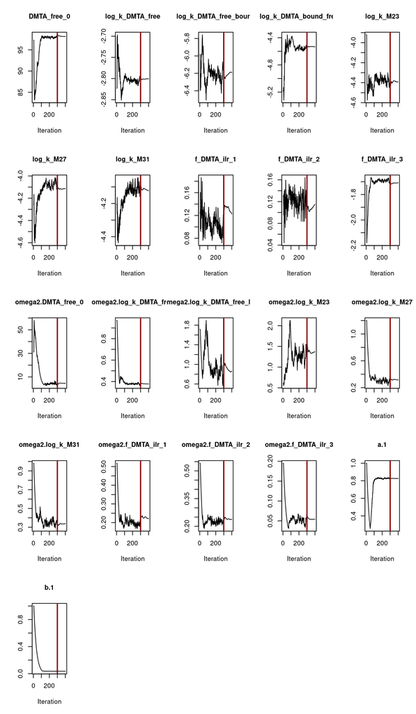

```r
plot(saem_sforb_path_1_tc_reduced$so, plot.type = "convergence")
```

For some parameters, for example for `f_DMTA_ilr_1` and `f_DMTA_ilr_2`, i.e. for two of the parameters determining the formation fractions of the parallel formation of the three metabolites, some movement of the parameters is still visible in the second phase of the algorithm. However, the amplitude of this movement is in the range of the amplitude towards the end of the first phase. Therefore, it is likely that an increase in iterations would not improve the parameter estimates very much, and it is proposed that the fit is acceptable. No numeric convergence criterion is implemented in saemix.

## Alternative check of parameter identifiability

As an alternative check of parameter identifiability (Duchesne et al. 2021), multistart runs were performed on the basis of the refined fit shown above.

```r
saem_sforb_path_1_tc_reduced_multi <- multistart(saem_sforb_path_1_tc_reduced,
  n = 32, cores = 10)
```

```
  (subscript) logical subscript too long
```

```r
print(saem_sforb_path_1_tc_reduced_multi)
```

```
<multistart> object with 32 fits:
 E OK
 7 25
OK: Fit terminated successfully
E: Error
```

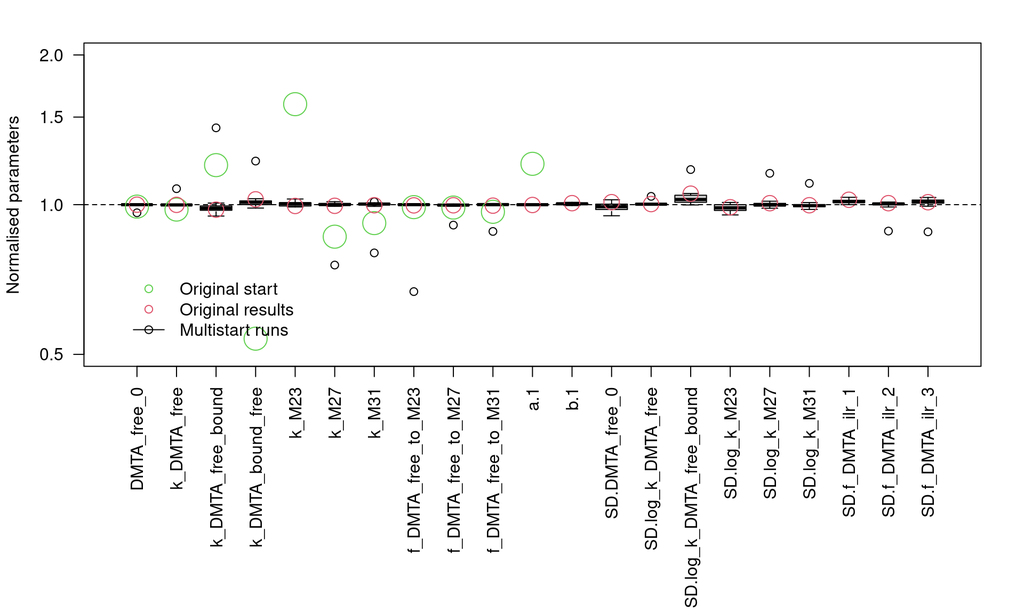

Parameter boxplots for the multistart runs that succeeded

```r
par(mar = c(12.1, 4.1, 2.1, 2.1))
parplot(saem_sforb_path_1_tc_reduced_multi, ylim = c(0.5, 2), las = 2)
```

However, visual analysis of the boxplot of the parameters obtained in the successful fits confirms that the results are sufficiently independent of the starting parameters, and there are no remaining ill-defined parameters.

# Plots of selected fits

The SFORB pathway fits with full and reduced parameter distribution model are shown below.

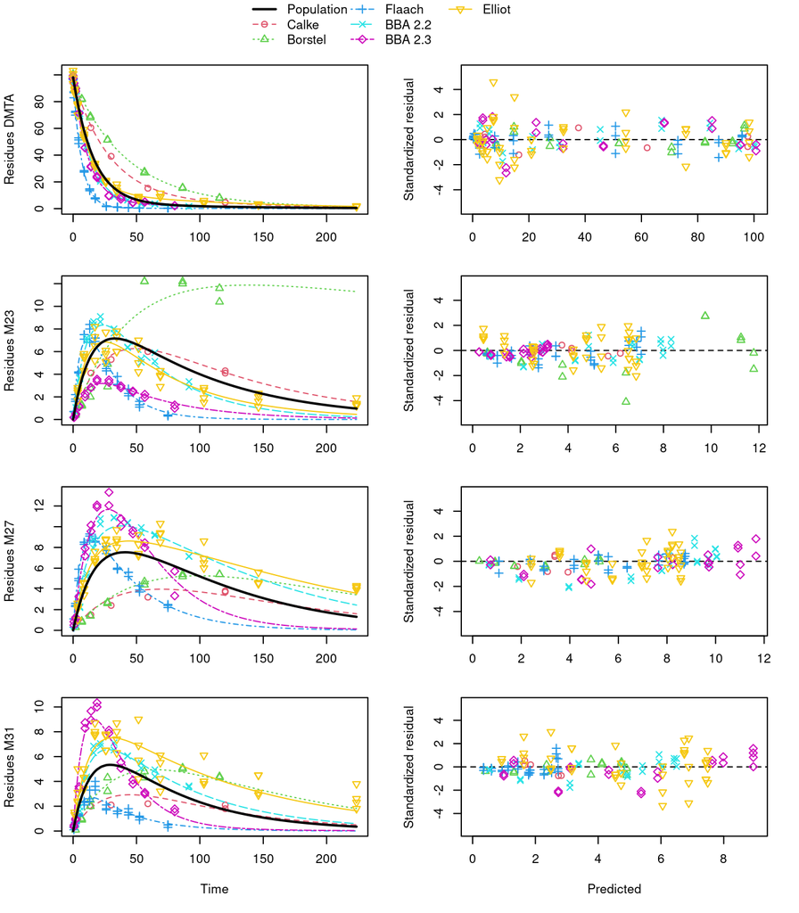

SFORB pathway fit with two-component error

```r
plot(saem_1[["sforb_path_1", "tc"]])
```

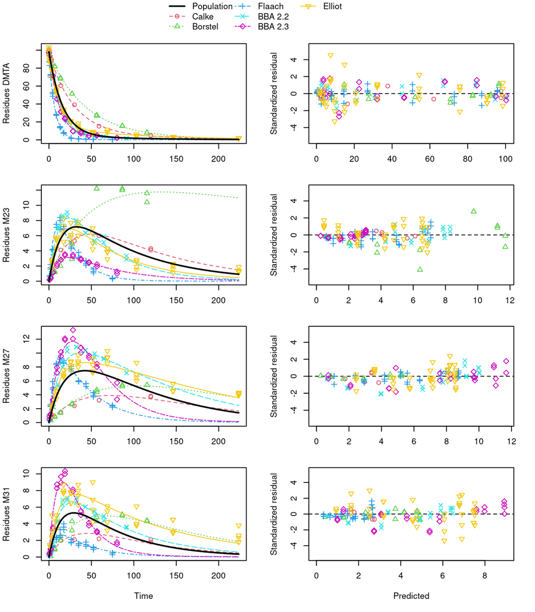

SFORB pathway fit with two-component error, reduced parameter model

```r
plot(saem_sforb_path_1_tc_reduced)
```

```r
stopCluster(cl)
```

# Conclusions

Pathway fits with SFO, FOMC, DFOP, SFORB and HS models for the parent compound could be successfully performed.

# Acknowledgements

The helpful comments by Janina Wöltjen of the German Environment Agency on earlier versions of this document are gratefully acknowledged.

# References

Duchesne, Ronan, Anissa Guillemin, Olivier Gandrillon, and Fabien Crauste. 2021. “Practical Identifiability in the Frame of Nonlinear Mixed Effects Models: The Example of the in Vitro Erythropoiesis.” *BMC Bioinformatics* 22 (478). https://doi.org/10.1186/s12859-021-04373-4.

Ranke, Johannes, Janina Wöltjen, Jana Schmidt, and Emmanuelle Comets. 2021. “Taking Kinetic Evaluations of Degradation Data to the Next Level with Nonlinear Mixed-Effects Models.” *Environments* 8 (8). https://doi.org/10.3390/environments8080071.

# Appendix

## Plots of hierarchical fits not selected for refinement

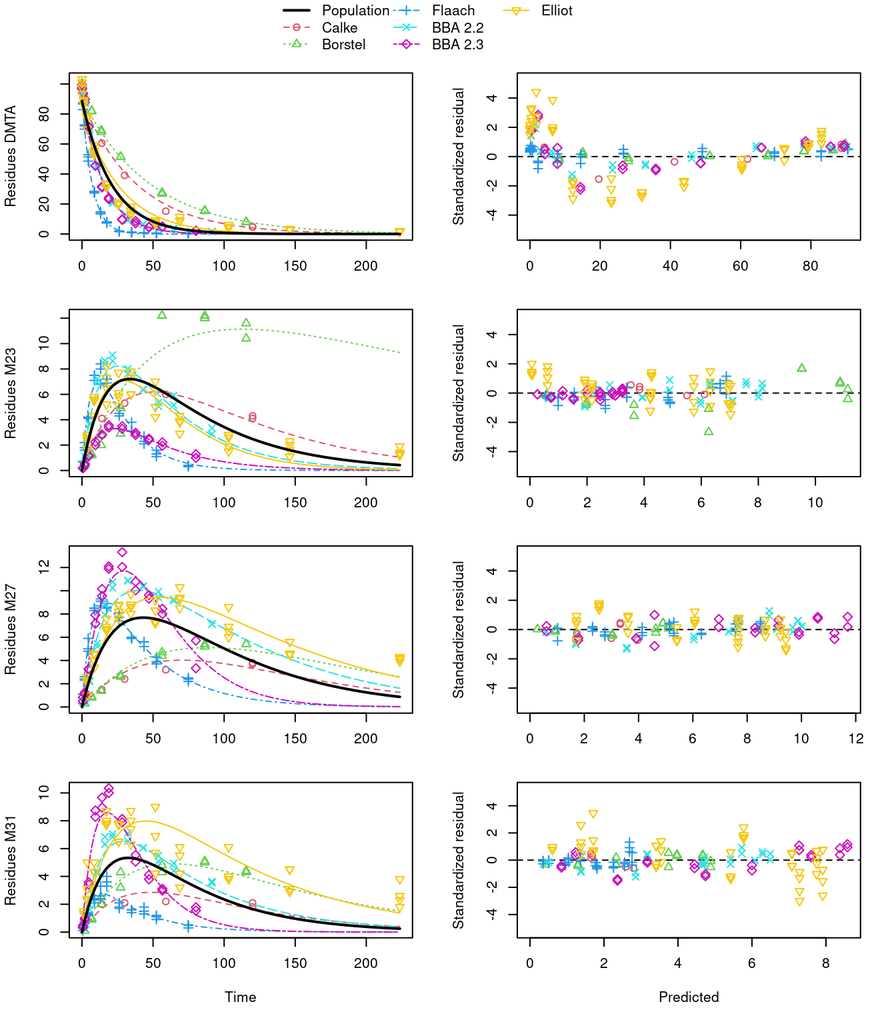

SFO pathway fit with two-component error

```r
plot(saem_1[["sfo_path_1", "tc"]])
```

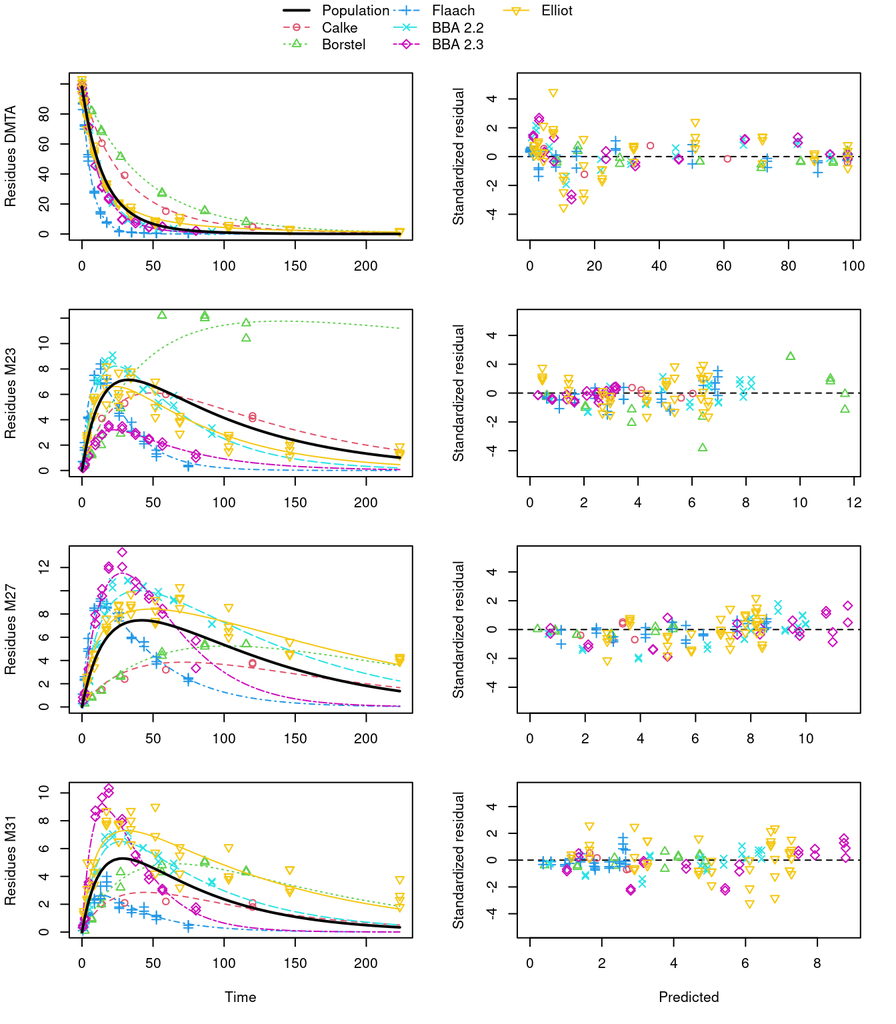

FOMC pathway fit with two-component error

```r
plot(saem_1[["fomc_path_1", "tc"]])
```

[figure not shown]

```r
plot(saem_1[["sforb_path_1", "tc"]])
```

## Hardware info

```
CPU model: AMD Ryzen 9 7950X 16-Core Processor
```

```
MemTotal:       64927788 kB
```